# Harmony_tutorial

2025-03-05

```r
if (!requireNamespace("BiocManager", quietly = TRUE))
    install.packages("BiocManager")
BiocManager::install("harmony")
BiocManager::install('glmGamPoi')
```

```r
library(harmony)
library(Seurat)
library(dplyr)
library(glmGamPoi)
```

Для цього туторіалу ми використовуватимемо дані з секвенування РНК поодиноких клітин з [Kang et al., 2017](https://www.nature.com/articles/nbt.4042) (Мононуклеарні клітини периферичної крові, контроль і стимульовані інтерфероном бета)

```r
data("pbmc_stim")
pbmcs_ctrl<-CreateSeuratObject(pbmc.ctrl, project="pbmc")
pbmcs_stim<-CreateSeuratObject(pbmc.stim, project="pbmc")
pbmcs<-merge(x=pbmcs_ctrl, y=pbmcs_stim, merge.data=TRUE)
```

Коли ми створили об’єкти Seurat, Варто додати колонку з кондицією до метаданих.

```r
Conditions<-c(rep("Control", length(pbmc.ctrl[1,])), rep("Stimulated", length(pbmc.stim[1,])))
pbmcs[["Condition"]]<-Conditions
```

Коли ви працюєте з сирими даними, варто відфільтрувати клітини з високою експресією мітохондріальних генів та клітини із занизькою кількістю прочитань. Щоб додати колонку з відсотками мітохондріальних генів, потрібно виконати наступний рядок коду:

```r
pbmcs[["percent.mt"]]<-PercentageFeatureSet(pbmcs, pattern="^MT-")
```

Тепер можна перевірити розподіли головних параметрів нашого Seurat об’єкту:

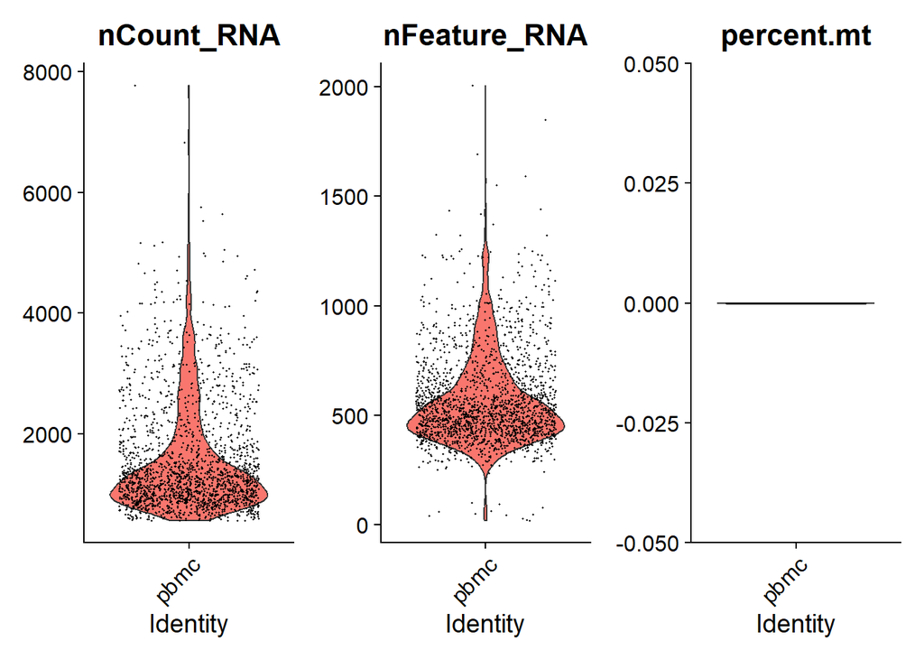

```r
VlnPlot(pbmcs, features = c("nCount_RNA","nFeature_RNA","percent.mt"))
```

Як бачимо, дані, що ми взяли у якості інпуту були вже попередньо відфільтровані, тому жодних додаткових маніпуляцій для фільтрування виконувати не потрібно. Але якби у вас на вході були сирі дані, вам обов’язково потрібно було би виконати quality control перед наступними кроками таким чином, як ви розглядали на занятті M2S03.

(ми з вами теж могли би працювати з сирими даними, та на жаль сайт NCBI не працює) :(

Давайте спершу поглянемо на те, як виглядатиме кластеризація без спеціальної інтеграції даних двох датасетів.

Виконаємо всі класичні етапи препроцесингу даних перед тим як робити кластеризацію з подальшою анотацією клітинних типів. Ми використовуватимемо для цього SCTransform:

```r
pbmcs <- pbmcs %>%
    NormalizeData() %>%
    FindVariableFeatures(selection.method = "vst", nfeatures = 2000) %>%
    ScaleData() %>%
    SCTransform(vars.to.regress = c("percent.mt"))
```

Після цього, ми виконуємо РСА та базуючись на ліктьовому графіку обираємо кількість головних компонент для подальшого аналізу.

```r
pbmcs <- RunPCA(pbmcs, assay = "SCT", npcs = 50)
```

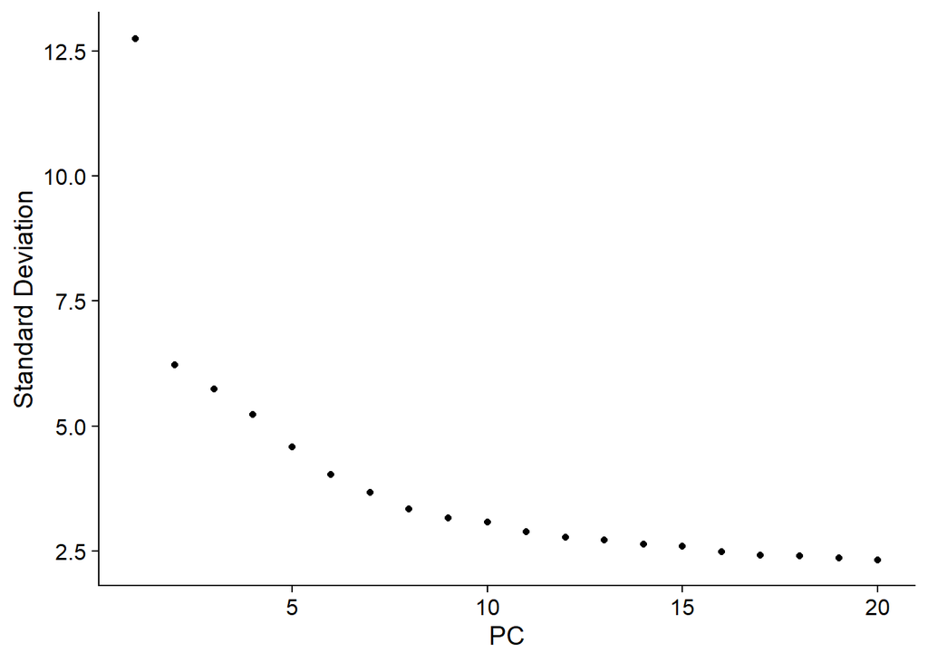

```r
ElbowPlot(pbmcs)
```

На цьому графіку позицію ліктя можна побачити приблизно на 7мій компоненті, отже для подальших дій ми використовуватимемо РС 1-7.

Давайте виконаємо нелінійне зменшення розмірності UMAP та поглянемо на отримані групи, що є в даних.

```r
pbmcs<-RunUMAP(pbmcs, reduction = "pca", assay = "SCT", dims = 1:7)
```

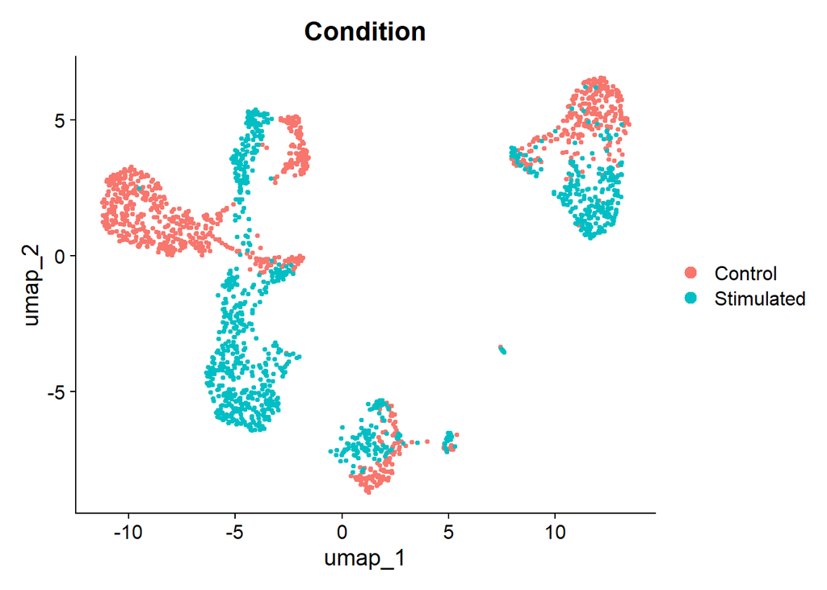

```r
DimPlot(pbmcs, reduction = "umap", group.by = "Condition")
```

Ми можемо спостерігати, що дані кластеризуються базуючись на кондиції: окремо бачимо групи клітин контролю, окремо групи стимульованих клітин. Це вносить суттєвий шум у подальший аналіз.

Саме тому варто провести інтеграцію датасетів за допомогою спеціальних функцій. У даному випадку це буде функція RunHarmony з пакету Harmony.

```r
harmonized_seurat <- RunHarmony(pbmcs,
                                group.by.vars = c("Condition"),
                                reduction = "pca", assay.use = "SCT", reduction.save = "harmony")
```

Скористаємось знову методом UMAP та глянемо чи змінилися групи на графіку.

```r
harmonized_seurat <- RunUMAP(harmonized_seurat, reduction = "harmony", assay = "SCT", dims = 1:7)
```

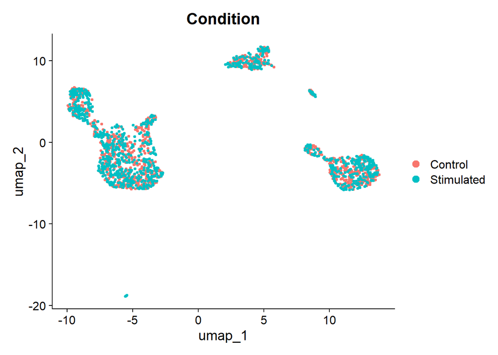

```r
DimPlot(harmonized_seurat, reduction = "umap", group.by = "Condition")
```

Тепер ми з більшою ймовірністю можемо припустити, що кластери репрезентують клітинні типи та/або стани, і тепер можна аналізувати диференційну експресію генів між кондиціями та знаходити клітинні субпопуляції, які значуще відрізняються між кондиціями :)